# Customer_Churn_Analysis

# 3. Que ciudad pierde más clientes

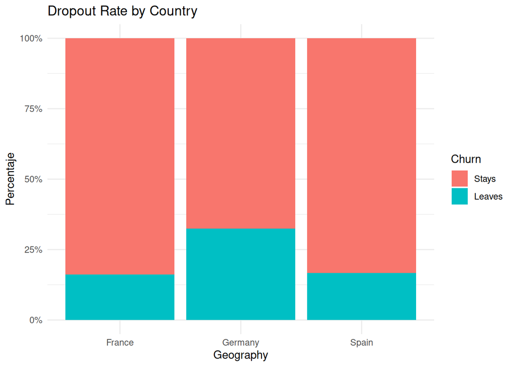

```r
## Alemanía tiene la mayor cantidad de abandono de clientes, a diferencia de Francia y España, lo que no es coherente porque su cartera es similar.
ggplot(df_clean, aes(x=Geography, fill = Churn))+
  geom_bar(position = "fill")+
  scale_y_continuous(labels = scales::percent)+
  theme_minimal()+
  labs(title = "Dropout Rate by Country", y= "Percentaje")
```

# 4. Análisis de variables numericas

#El abandono de cleintes es debido a su récord crediticio?, se busca saber si la solvencia crediticia. Sin embargo se puede observar que, tanto con buen récord o bajo récord, el cliente se va. #Adicional, que, se obvervan unos outliers en Leaves, dando a notas que hay clientes con un récord inusualmente bajo que dejaron el banco o fueron dados de baja.

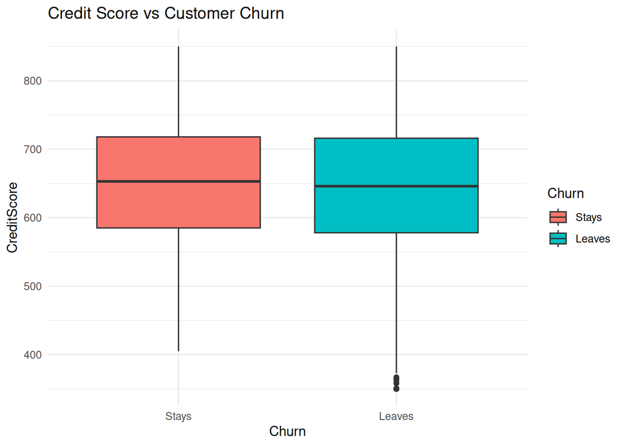

```r
# Analysis of Numerical Variables
# Is customer churn due the credit score ?
ggplot(df_clean, aes(x= Churn, y=CreditScore , fill= Churn))+
  geom_boxplot()+
  theme_minimal()+
  labs(title = "Credit Score vs Customer Churn")
```

# 5. Análisis de desbalance de clases

#Podemos notar que de un total de 10K registros un aproximado de 20% se va, está cifra es significativa, lo que requeriría acciones inmediatas.

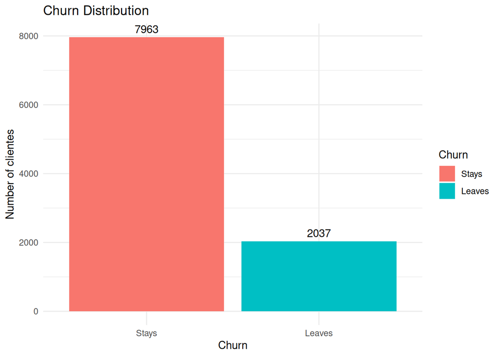

```r
# Churn Distribution
ggplot(df_clean, aes(x= Churn, fill = Churn))+
  geom_bar()+
  geom_text(stat = 'count', aes(label = ..count..), vjust=-0.5)+
  theme_minimal()+
  labs(title = "Churn Distribution", y= "Number of clientes")
```

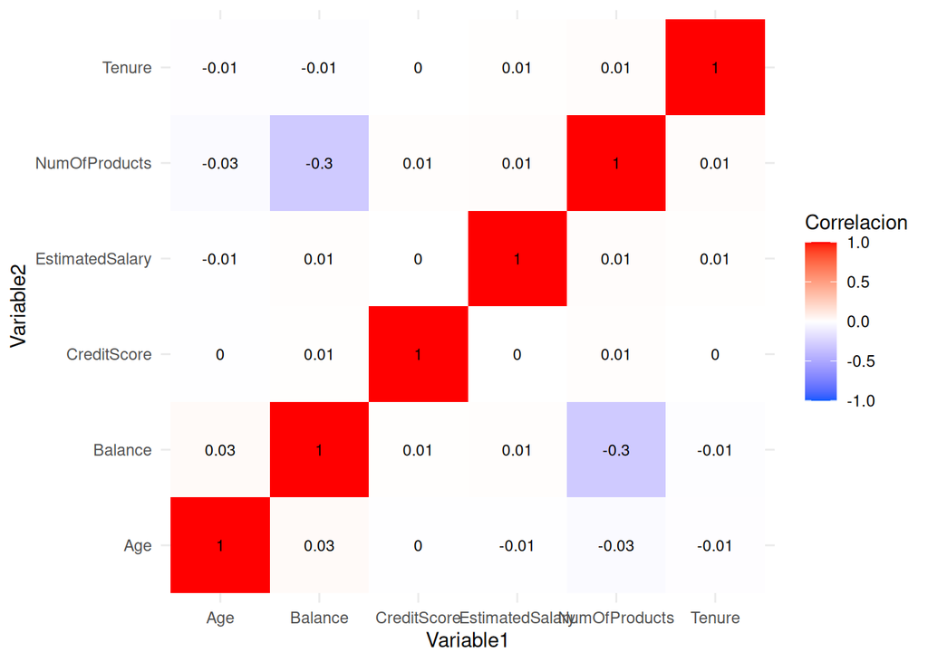

```r
# Corr Matrix, we need to convert the text data into a numeric data
cor_data <- df_clean %>%
  select(CreditScore, Age, Tenure, Balance, NumOfProducts, EstimatedSalary) %>%
  mutate(across(everything(), as.numeric))

cor_matrix <- cor(cor_data)
cor_df <- as.data.frame(cor_matrix)
cor_df <- rownames_to_column(cor_df, var= "Variable1")
cor_long <- pivot_longer(cor_df, cols = -Variable1, names_to = "Variable2", values_to = "Correlacion")

ggplot(cor_long, aes(x = Variable1, y = Variable2, fill = Correlacion)) +
  geom_tile() +
  geom_text(aes(label = round(Correlacion, 2)), size = 3) +
  scale_fill_gradient2(low = "#075AFF", high = "#FF0000", mid = "white", limit = c(-1,1)) +
  theme_minimal()
```